# Project: No-show Appointments Data Analysis

- Introduction
- Data Wrangling
- Exploratory Data Analysis
- Conclusions

## Introduction

### Dataset Description

> This analysis investigates possible reasons why patients do not show fup for scheduled appointments. The dataset collects information of over 110,000 medical appointments made by over 60,000 patients in Brazil. It was collected in April to June 2016 and it is focused on characteristics of patients as well as their presence or absence from scheduled medical appointments.

> This dataset contains 14 variables as follows:

> **PatientId**: Identification of a patient

> **AppointmentID**: Identification of each appointment

> **Gender**: Male or Female

> **AppointmentDay**: The day of the actual appointment, when they have to visit the doctor.

> **ScheduledDay**: The day someone called or registered the appointment, this is before appointment of course.

> **Age**: How old is the patient.

> **Neighbourhood**: Where the appointment takes place.

> **Scholarship**: Indicates whether or not the patient is enrolled in Brazilian social welfare program Bolsa Família and it contains two values: 0 refers to be not enrolled and 1 refers to be enrolled.

> **Hipertension**: Indicates if the patient is hypertensive in binary values (0 for False, 1 for True)

> **Diabetes**: Indicates if the patient is diabetic in binary values (0 for False, 1 for True)

> **Alcoholism**: Indicates if the patient is an alcoholic in binary values (0 for False, 1 for True)

> **Handcap**: Indicates if the patient is handicapped in binary values (0 for False, 1 for True)

> **SMS_received**: 1 or more messages sent to the patient expressed in binary values (0 for False, 1 for True)

> **No-show**: ‘No’ if the patient showed up to their appointment, and ‘Yes’ if they did not show up.

> This analysis will be done using the No-show variable as our dependent variable while other variables will be used as independent variables.

### Question(s) for Analysis

> This Project will be exploring and providing insights to the following questions:

> Does the age and gender of a patient affect their attendance to appointments?

> Does scholarship from the Brazilian welfare program affect No-show?

> Does patients diagnosis affect attendance to appointments?

> Does increase in number of waiting days affect patients attendance to appointments?

> What is the relationship between Neighbourhood and their showing up for appointments?

> Does receiving SMS reminder affect patients attendance to appointments?

> To provide answers to the questions stated above, we would clean the data and explore all the variables to seek any correlation between all independent features and how it affects patients attendance to scheduled appointments.

```python
# Import necessary libraries for the investigation
import numpy as np
import pandas as pd
import matplotlib.pyplot as plt
import seaborn as sns
% matplotlib inline
```

## Data Wrangling

### General Properties

```python
# Load your data and print out a few lines at random
url = "Database_No_show_appointments/noshowappointments-kagglev2-may-2016.csv"
df = pd.read_csv(url)
df.sample(10)
```

|  | PatientId | AppointmentID | Gender | ScheduledDay | AppointmentDay | Age | Neighbourhood | Scholarship | Hipertension | Diabetes | Alcoholism | Handcap | SMS_received | No-show |
| --- | --- | --- | --- | --- | --- | --- | --- | --- | --- | --- | --- | --- | --- | --- |
| 5233 | 3.892232e+12 | 5733311 | F | 2016-05-24T13:41:17Z | 2016-05-31T00:00:00Z | 57 | PRAIA DO SUÁ | 0 | 0 | 0 | 0 | 0 | 1 | No |
| 100169 | 2.946724e+13 | 5762793 | F | 2016-06-02T08:10:14Z | 2016-06-02T00:00:00Z | 16 | TABUAZEIRO | 0 | 0 | 0 | 0 | 1 | 0 | No |
| 7858 | 9.854432e+14 | 5698423 | F | 2016-05-16T07:33:49Z | 2016-05-16T00:00:00Z | 13 | JESUS DE NAZARETH | 0 | 0 | 0 | 0 | 0 | 0 | No |
| 4163 | 6.542388e+13 | 5632082 | F | 2016-04-28T07:39:46Z | 2016-05-06T00:00:00Z | 22 | MARIA ORTIZ | 0 | 0 | 0 | 0 | 0 | 1 | Yes |
| 43548 | 3.638421e+12 | 5659155 | F | 2016-05-04T13:16:50Z | 2016-05-06T00:00:00Z | 3 | ANDORINHAS | 0 | 0 | 0 | 0 | 0 | 0 | Yes |
| 20583 | 5.856525e+13 | 5676967 | M | 2016-05-09T17:07:53Z | 2016-05-16T00:00:00Z | 3 | DO QUADRO | 0 | 0 | 0 | 0 | 0 | 0 | No |
| 8127 | 9.693973e+12 | 5664403 | F | 2016-05-05T12:08:53Z | 2016-05-09T00:00:00Z | 64 | JARDIM CAMBURI | 0 | 1 | 1 | 0 | 0 | 0 | No |
| 102872 | 2.552524e+14 | 5163351 | F | 2015-12-15T10:15:50Z | 2016-06-08T00:00:00Z | 47 | MARUÍPE | 0 | 1 | 0 | 0 | 0 | 1 | Yes |
| 6087 | 5.536265e+14 | 5698719 | M | 2016-05-16T07:48:13Z | 2016-05-18T00:00:00Z | 10 | CONQUISTA | 0 | 0 | 0 | 0 | 0 | 0 | Yes |
| 26514 | 7.856561e+12 | 5677825 | F | 2016-05-10T07:42:10Z | 2016-05-13T00:00:00Z | 17 | COMDUSA | 1 | 0 | 0 | 0 | 0 | 0 | No |

```python
# Check number of rows and columns
df.shape
```

```
(110527, 14)
```

```python
# Check information of all columns
df.info()
```

```
<class 'pandas.core.frame.DataFrame'>
RangeIndex: 110527 entries, 0 to 110526
Data columns (total 14 columns):
PatientId         110527 non-null float64
AppointmentID     110527 non-null int64
Gender            110527 non-null object
ScheduledDay      110527 non-null object
AppointmentDay    110527 non-null object
Age               110527 non-null int64
Neighbourhood     110527 non-null object
Scholarship       110527 non-null int64
Hipertension      110527 non-null int64
Diabetes          110527 non-null int64
Alcoholism        110527 non-null int64
Handcap           110527 non-null int64
SMS_received      110527 non-null int64
No-show           110527 non-null object
dtypes: float64(1), int64(8), object(5)
memory usage: 11.8+ MB
```

```python
# Check counts of unique values of each column
df.nunique()
```

```
PatientId          62299
AppointmentID     110527
Gender                 2
ScheduledDay      103549
AppointmentDay        27
Age                  104
Neighbourhood         81
Scholarship            2
Hipertension           2
Diabetes               2
Alcoholism             2
Handcap                5
SMS_received           2
No-show                2
dtype: int64
```

```python
# Check statistical description of the columns
df.describe()
```

|  | PatientId | AppointmentID | Age | Scholarship | Hipertension | Diabetes | Alcoholism | Handcap | SMS_received |
| --- | --- | --- | --- | --- | --- | --- | --- | --- | --- |
| count | 1.105270e+05 | 1.105270e+05 | 110527.000000 | 110527.000000 | 110527.000000 | 110527.000000 | 110527.000000 | 110527.000000 | 110527.000000 |
| mean | 1.474963e+14 | 5.675305e+06 | 37.088874 | 0.098266 | 0.197246 | 0.071865 | 0.030400 | 0.022248 | 0.321026 |
| std | 2.560949e+14 | 7.129575e+04 | 23.110205 | 0.297675 | 0.397921 | 0.258265 | 0.171686 | 0.161543 | 0.466873 |
| min | 3.921784e+04 | 5.030230e+06 | -1.000000 | 0.000000 | 0.000000 | 0.000000 | 0.000000 | 0.000000 | 0.000000 |
| 25% | 4.172614e+12 | 5.640286e+06 | 18.000000 | 0.000000 | 0.000000 | 0.000000 | 0.000000 | 0.000000 | 0.000000 |
| 50% | 3.173184e+13 | 5.680573e+06 | 37.000000 | 0.000000 | 0.000000 | 0.000000 | 0.000000 | 0.000000 | 0.000000 |
| 75% | 9.439172e+13 | 5.725524e+06 | 55.000000 | 0.000000 | 0.000000 | 0.000000 | 0.000000 | 0.000000 | 1.000000 |
| max | 9.999816e+14 | 5.790484e+06 | 115.000000 | 1.000000 | 1.000000 | 1.000000 | 1.000000 | 4.000000 | 1.000000 |

```python
# Check datatypes of each column
df.dtypes
```

```
PatientId         float64
AppointmentID       int64
Gender             object
ScheduledDay       object
AppointmentDay     object
Age                 int64
Neighbourhood      object
Scholarship         int64
Hipertension        int64
Diabetes            int64
Alcoholism          int64
Handcap             int64
SMS_received        int64
No-show            object
dtype: object
```

```python
# Check for missing data in each columnn
df.isnull().sum()
```

```
PatientId         0
AppointmentID     0
Gender            0
ScheduledDay      0
AppointmentDay    0
Age               0
Neighbourhood     0
Scholarship       0
Hipertension      0
Diabetes          0
Alcoholism        0
Handcap           0
SMS_received      0
No-show           0
dtype: int64
```

```python
# Inspect data for duplicates
df.duplicated().sum()
```

```
0
```

> From the above, the following were observed:

> There are 110,527 rows and 14 columns

> There are no duplicate rows

> There are no missing data

> Age has a negative value

> The column names would need to be edited

> Scheduled day and appointment day are string data types

> There are 62,299 patients

> Handicap has 5 unique values instead of binary values

### Data Cleaning

```python
# After discussing the structure of the data and any problems that need to be
#   cleaned, perform those cleaning steps in the second part of this section.

# Rename each column and change to lower case
df = df.rename(columns= {'PatientId': 'patient_id', 'AppointmentID': 'appointment_id', 'Gender': 'gender',
                          'ScheduledDay': 'scheduled_day', 'AppointmentDay': 'appointment_day', 'Age': 'age',
                          'Neighbourhood': 'neighbourhood', 'Scholarship': 'scholarship', 'Hipertension': 'hypertension',
                          'Diabetes': 'diabetes', 'Handcap': 'handicap', 'Alcoholism': 'alcoholism',
                          'SMS_received': 'sms_received', 'No-show': 'no_show'})

# Check for desired result
df.head(1)
```

|  | patient_id | appointment_id | gender | scheduled_day | appointment_day | age | neighbourhood | scholarship | hypertension | diabetes | alcoholism | handicap | sms_received | no_show |
| --- | --- | --- | --- | --- | --- | --- | --- | --- | --- | --- | --- | --- | --- | --- |
| 0 | 2.987250e+13 | 5642903 | F | 2016-04-29T18:38:08Z | 2016-04-29T00:00:00Z | 62 | JARDIM DA PENHA | 0 | 1 | 0 | 0 | 0 | 0 | No |

> The columns have been renamed, converted to lowercase and separated with underscores.

```python
# Change datatypes of 'patient_id' and 'appointment_id' to strings
df['patient_id'] = df['patient_id'].astype(str)
df['appointment_id'] = df['appointment_id'].astype(str)
```

> Patient ID and Appointment ID have been changed to strings data type from float and integer respectively.

```python
# Change 'scheduled_day' and 'appointment_day' to datetime data type
df['scheduled_day'] = pd.to_datetime(df['scheduled_day'])
df['appointment_day'] = pd.to_datetime(df['appointment_day'])
```

> Scheduled day and Appointment day have been changed to date-time data types

```python
# Check result
df.dtypes
```

```
patient_id                 object
appointment_id             object
gender                     object
scheduled_day      datetime64[ns]
appointment_day    datetime64[ns]
age                         int64
neighbourhood              object
scholarship                 int64
hypertension                int64
diabetes                    int64
alcoholism                  int64
handicap                    int64
sms_received                int64
no_show                    object
dtype: object
```

```python
# Check for rows were age has negative values
df[df['age'] < 0]
```

|  | patient_id | appointment_id | gender | scheduled_day | appointment_day | age | neighbourhood | scholarship | hypertension | diabetes | alcoholism | handicap | sms_received | no_show |
| --- | --- | --- | --- | --- | --- | --- | --- | --- | --- | --- | --- | --- | --- | --- |
| 99832 | 4.65943158731e+14 | 5775010 | F | 2016-06-06 08:58:13 | 2016-06-06 | -1 | ROMÃO | 0 | 0 | 0 | 0 | 0 | 0 | No |

> There is a single row where age value is negative.

```python
# Drop the row with a negative age value
df.drop(df[df['age'] < 0].index, inplace = True)
```

> This has to be deleted because it is an anomaly.

```python
# Convert handicap variable to binary
df.handicap.unique()
```

```
array([0, 1, 2, 3, 4])
```

> Handicap should have only values 0 or 1

```python
# Replace [2, 3, 4] by 1 and confirm result
df['handicap'].replace(to_replace =[2, 3, 4], value =1,inplace=True)
df.handicap.unique()
```

```
array([0, 1])
```

> values 2, 3 & 4 have been replaced with 1

```python
# Create a column of days patients have to wait to meet their scheduled appointment
df['wait_days'] = ((df['appointment_day'] - df['scheduled_day']).dt.days) + 1
```

> A column wait days has been created being the period between scheduled day and appointment day.

```python
# Convert the wait_days column to integer data type
df['wait_days'] = df['wait_days'].astype('str')
df['wait_days'] = df['wait_days'].apply(lambda x: x.split()[0])
df['wait_days'] = df['wait_days'].astype('int')
```

> wait_days has been converted to integer data type

```python
# Check result
df.describe()
```

|  | age | scholarship | hypertension | diabetes | alcoholism | handicap | sms_received | wait_days |
| --- | --- | --- | --- | --- | --- | --- | --- | --- |
| count | 110526.000000 | 110526.000000 | 110526.000000 | 110526.000000 | 110526.000000 | 110526.000000 | 110526.000000 | 110526.000000 |
| mean | 37.089219 | 0.098266 | 0.197248 | 0.071865 | 0.030400 | 0.020276 | 0.321029 | 10.183794 |
| std | 23.110026 | 0.297676 | 0.397923 | 0.258266 | 0.171686 | 0.140943 | 0.466874 | 15.255034 |
| min | 0.000000 | 0.000000 | 0.000000 | 0.000000 | 0.000000 | 0.000000 | 0.000000 | -6.000000 |
| 25% | 18.000000 | 0.000000 | 0.000000 | 0.000000 | 0.000000 | 0.000000 | 0.000000 | 0.000000 |
| 50% | 37.000000 | 0.000000 | 0.000000 | 0.000000 | 0.000000 | 0.000000 | 0.000000 | 4.000000 |
| 75% | 55.000000 | 0.000000 | 0.000000 | 0.000000 | 0.000000 | 0.000000 | 1.000000 | 15.000000 |
| max | 115.000000 | 1.000000 | 1.000000 | 1.000000 | 1.000000 | 1.000000 | 1.000000 | 179.000000 |

> Wait days column has negative values which does not make sense for our analysis. All rows having negative wait days should be dropped from our dataset.

```python
# Check distriubution of wait days
df.wait_days.value_counts().sort_index().head()
```

```
-6        1
-1        4
 0    38562
 1     5213
 2     6725
Name: wait_days, dtype: int64
```

```python
# Drop all rows with negative wait days
df.drop(df[df['wait_days'] < 0].index, inplace = True)
```

> All rows with negative wait days value have been expunged from the dataset

```python
# Check data types sfter cleaning
df.dtypes
```

```
patient_id                 object
appointment_id             object
gender                     object
scheduled_day      datetime64[ns]
appointment_day    datetime64[ns]
age                         int64
neighbourhood              object
scholarship                 int64
hypertension                int64
diabetes                    int64
alcoholism                  int64
handicap                    int64
sms_received                int64
no_show                    object
wait_days                   int64
dtype: object
```

```python
# Check data statistics after cleaning
df.describe()
```

|  | age | scholarship | hypertension | diabetes | alcoholism | handicap | sms_received | wait_days |
| --- | --- | --- | --- | --- | --- | --- | --- | --- |
| count | 110521.000000 | 110521.000000 | 110521.000000 | 110521.000000 | 110521.000000 | 110521.000000 | 110521.000000 | 110521.000000 |
| mean | 37.089386 | 0.098271 | 0.197257 | 0.071869 | 0.030401 | 0.020259 | 0.321043 | 10.184345 |
| std | 23.109885 | 0.297682 | 0.397929 | 0.258272 | 0.171690 | 0.140884 | 0.466879 | 15.255153 |
| min | 0.000000 | 0.000000 | 0.000000 | 0.000000 | 0.000000 | 0.000000 | 0.000000 | 0.000000 |
| 25% | 18.000000 | 0.000000 | 0.000000 | 0.000000 | 0.000000 | 0.000000 | 0.000000 | 0.000000 |
| 50% | 37.000000 | 0.000000 | 0.000000 | 0.000000 | 0.000000 | 0.000000 | 0.000000 | 4.000000 |
| 75% | 55.000000 | 0.000000 | 0.000000 | 0.000000 | 0.000000 | 0.000000 | 1.000000 | 15.000000 |
| max | 115.000000 | 1.000000 | 1.000000 | 1.000000 | 1.000000 | 1.000000 | 1.000000 | 179.000000 |

```python
# Check number of rows and columns of the data set
df.shape
```

```
(110521, 15)
```

```python
# Preview a sample of the cleaned dataset
df.sample(5)
```

|  | patient_id | appointment_id | gender | scheduled_day | appointment_day | age | neighbourhood | scholarship | hypertension | diabetes | alcoholism | handicap | sms_received | no_show | wait_days |
| --- | --- | --- | --- | --- | --- | --- | --- | --- | --- | --- | --- | --- | --- | --- | --- |
| 7924 | 5.95972322262e+12 | 5706076 | F | 2016-05-17 07:49:42 | 2016-05-17 | 14 | JESUS DE NAZARETH | 0 | 0 | 0 | 0 | 0 | 0 | No | 0 |
| 66512 | 9.23358566966e+12 | 5715750 | F | 2016-05-18 15:02:29 | 2016-05-18 | 27 | JARDIM CAMBURI | 0 | 0 | 0 | 0 | 0 | 0 | No | 0 |
| 91763 | 3262899978.0 | 5757908 | M | 2016-06-01 09:59:46 | 2016-06-08 | 9 | SÃO PEDRO | 0 | 0 | 0 | 0 | 0 | 1 | Yes | 7 |
| 74990 | 8.99332686936e+12 | 5744549 | F | 2016-05-30 10:25:56 | 2016-05-30 | 30 | ILHA DAS CAIEIRAS | 0 | 0 | 0 | 0 | 0 | 0 | No | 0 |
| 3358 | 4.17588844987e+12 | 5615976 | F | 2016-04-25 13:19:05 | 2016-05-30 | 45 | RESISTÊNCIA | 0 | 0 | 0 | 0 | 0 | 1 | Yes | 35 |

> After cleaning, we have 110,521 rows and 15 columns

## Exploratory Data Analysis

> In this section, we would make use of both single and multiple variable explorations to investigate different features and their relationship with appointment no-show. This would provide the information needed to answer the questions posed earlier in this investigation.

> First, let us explore these single variables: age, alcoholism, diabetes, hypertension, handicap, scholarship, SMS received and wait days.

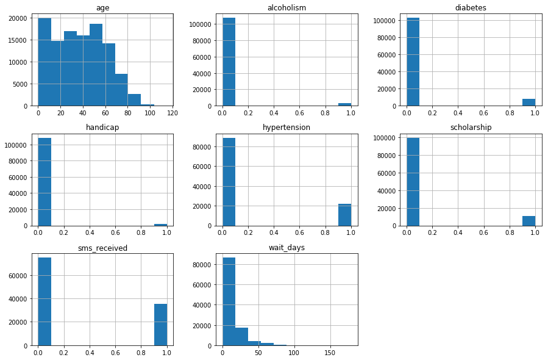

```python
# Taking these variables and plotting in a histogram
df.hist(figsize = (15,10));
```

> Most appointments are booked by patients within the age of 0 to 60 years and there is a sharp reduction of appointments made by older patients.

> Patients diagnosed with alcoholism, diabetes and disability who made appointments are fewer compared to hypertensive ones which is about 20%.

> Wait days: The distribution of wait days is sharply right-skewed. This means that most appointments are booked close to the scheduled day.

> SMS received: About 32% of appointments made received SMS notification while roughly 10% of appointments were made by patients on scholarship.

> Now let us explore gender distribution and appointment no-show.

```
gender
F    71836
M    38685
Name: appointment_id, dtype: int64
```

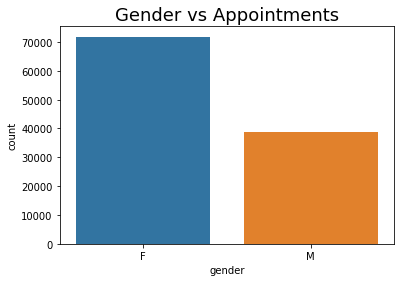

```python
# Chart the distribution of gender counts
sns.countplot(df['gender']);
plt.title('Gender vs Appointments',fontsize=18)
df.groupby(df.gender).appointment_id.count()
```

> From the above visualization, 65% of appointments were made by females; almost twice made by males.

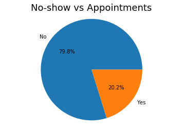

```
No     88207
Yes    22314
Name: no_show, dtype: int64
```

```python
# Create a pie chart of No-show distribution
plt.pie(df.no_show.value_counts(),labels=['No', 'Yes'],autopct='%1.1f%%')
plt.title('No-show vs Appointments', fontsize=18)
plt.axis('equal')
plt.show();
df.no_show.value_counts()
```

> 20% of appointments made were a no-show.

From the above single variable exploration, we find that:

- most patients range from 0 to 60 years
- most are neither diabetic, alcoholics nor hypertensive
- most patients are not handicapped
- most did not receive an sms
- most are not in the "Bolsa familia" scholarship program
- 79.8% did not miss the appointment
- most patients had appointments scheduled within a week of the scheduled day

> To answer the questions that prompted this dataset investigation, the relationship between multiple variables would be explored below especially as it relates to appointment show-up.

### Does the age and gender of a patient affect their attendance to appointments?

#### Age distribution vs Appointment show-up

> Let us analyze the relationship between patient's age and appointment show-up. First, we would split the age distribution into five age groups.

```python
# Distribution of age by category
df['age_category'] = pd.cut(df.age,bins=[-1,2,17,39,60,116],labels=['Infants','Children','Youth','Adults', 'Seniors'],)
```

> Age category was created by splitting the age distribution of patients into five categories: infants, children, youth, adults and seniors.

> Next, we explore the distribution of the age category.

```
age_category
Infants      7430
Children    19948
Youth       31899
Adults      31483
Seniors     19761
Name: appointment_id, dtype: int64
```

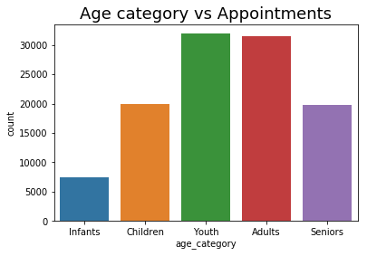

```python
# Chart the age category
sns.countplot(df['age_category']);
plt.title('Age category vs Appointments', fontsize=18)
df.groupby('age_category').appointment_id.count()
```

> Most patients are youth and adults within the age range of 18 to 59years

> Let us plot a bar chart for age category against appointment show-up

```
age_category  no_show
Infants       No          6124
              Yes         1306
Children      No         15258
              Yes         4690
Youth         No         24478
              Yes         7421
Adults        No         25591
              Yes         5892
Seniors       No         16756
              Yes         3005
Name: no_show, dtype: int64
```

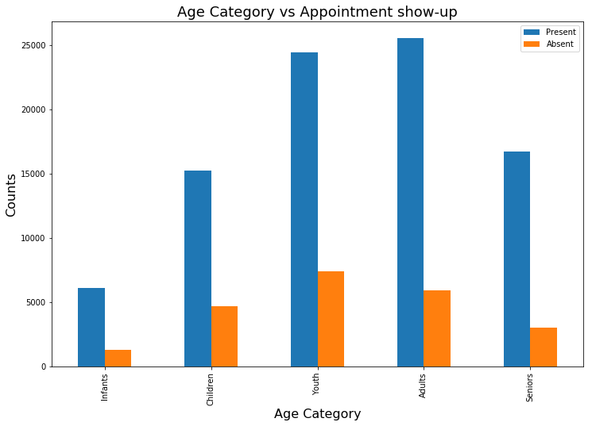

```python
# Plot a bar chart to show age category vs appointment show-up
df_age = df.groupby('age_category')['no_show'].value_counts().unstack()
df_age.plot(kind = 'bar',figsize= (12,8))
plt.ylabel('Counts', fontsize=16)
plt.xlabel('Age Category', fontsize=16)
plt.title('Age Category vs Appointment show-up', fontsize=18)
plt.legend(['Present','Absent']);
df.groupby('age_category')['no_show'].value_counts()
```

> Infants and seniors tend to show up for their appointments more than other age categories

#### Gender versus appointment show-up

> Now we plot the relationship between gender and appointment show-up using a bar chart

```
no_show  gender
No       F         57245
         M         30962
Yes      F         14591
         M          7723
Name: gender, dtype: int64
```

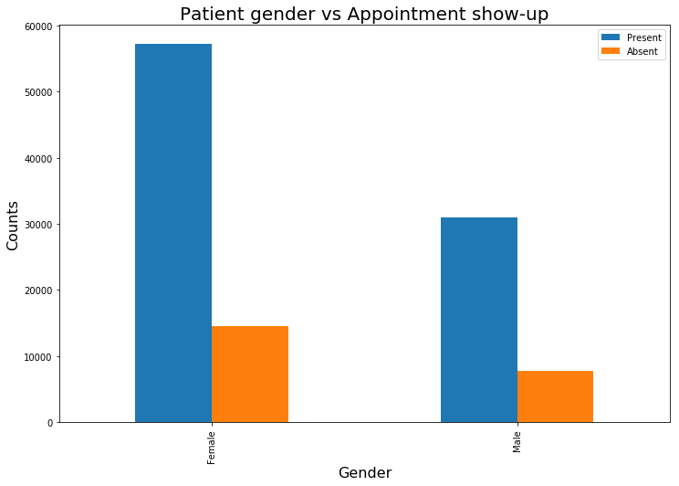

```python
df_gender = df.groupby('gender')['no_show'].value_counts().unstack()
df_gender.plot(kind = 'bar',figsize= (12,8))
plt.ylabel('Counts', fontsize=16)
plt.xlabel('Gender', fontsize=16)
plt.xticks([0,1], ['Female', 'Male'])
plt.title('Patient gender vs Appointment show-up', fontsize=20)
plt.legend(['Present','Absent']);
df.groupby('no_show')['gender'].value_counts()
```

> There is almost twice as much appointments booked by females compared to males. Though, there seems to be no significant distinction between male and female rate of show up for appointment

### Does the social welfare scholarship affect attendance to appointments?

> Plot a bar chart for scholarship against appointment show-up to analyze the relationship between these variables

```
scholarship  no_show
0            No         79924
             Yes        19736
1            No          8283
             Yes         2578
Name: no_show, dtype: int64
```

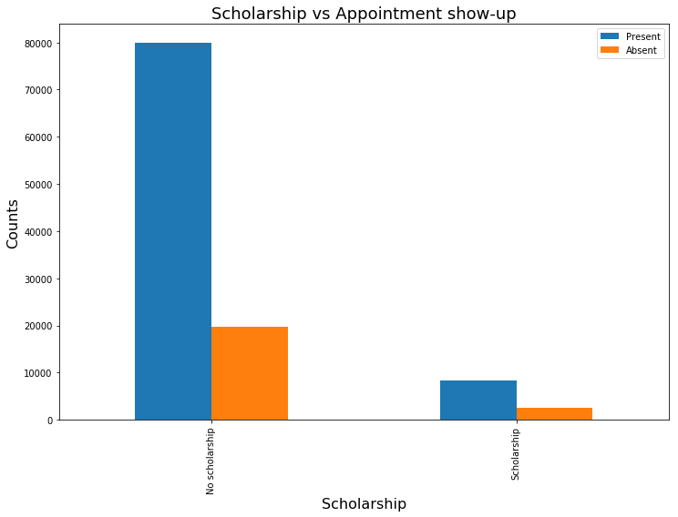

```python
df_sch = df.groupby('scholarship')['no_show'].value_counts().unstack()
df_sch.plot(kind = 'bar',figsize= (12,8))
plt.ylabel('Counts', fontsize=16)
plt.xlabel('Scholarship', fontsize=16)
plt.xticks([0,1], ['No scholarship', 'Scholarship'])
plt.title('Scholarship vs Appointment show-up', fontsize=18)
plt.legend(['Present','Absent']);
df.groupby('scholarship')['no_show'].value_counts()
```

### Does patients diagnosis affect attendance to appointments?

> Plot a bar chart of the distribution of all hypertension, diabetes, alcoholism and handicap values against appointment show-up

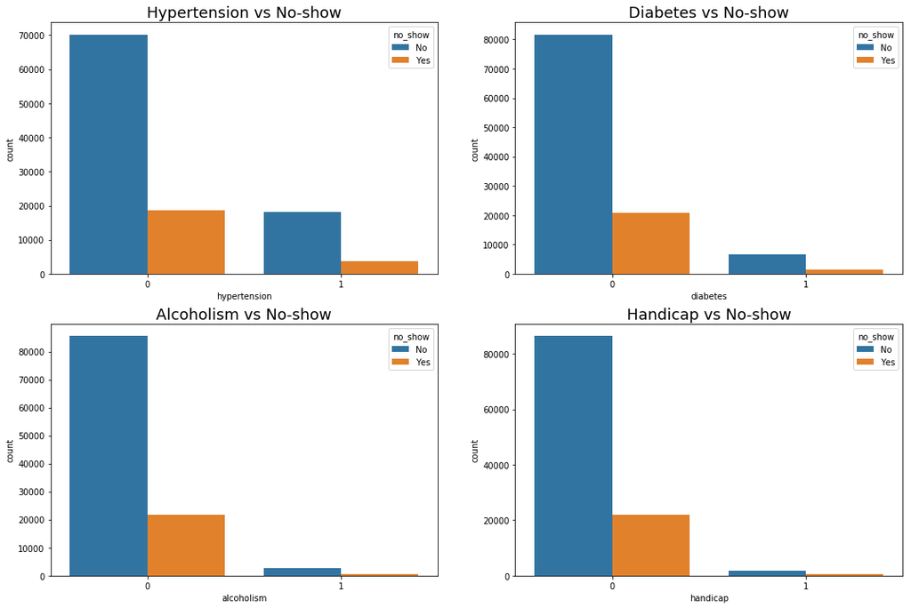

```python
f,ax=plt.subplots(2,2,figsize=(18,12))
sns.countplot(x='hypertension', data=df, hue='no_show', ax=ax[0,0])
ax[0,0].set_title('Hypertension vs No-show',fontsize=18)
sns.countplot(x='diabetes', data=df, hue='no_show', ax=ax[0,1])
ax[0,1].set_title('Diabetes vs No-show',fontsize=18)
sns.countplot(x='alcoholism', data=df, hue='no_show', ax=ax[1,0])
ax[1,0].set_title('Alcoholism vs No-show',fontsize=18)
sns.countplot(x='handicap', data=df, hue='no_show', ax=ax[1,1])
ax[1,1].set_title('Handicap vs No-show',fontsize=18);
```

### Does increase in number of waiting days affect showing up for appointments?

> To get a better visualization of waiting days distribution against appointment show-up, we would create a wait period category by splitting the distribution into 5 groups: A day, A week, 2 weeks, A month, 2 to 4 months

```python
# Create a wait period category
df['wait_period'] = pd.cut(df.wait_days,bins=[-1,1,7,14,30,120],labels=['A day','A week','2 weeks','A month', '2 to 4months'],)
```

> Plot a bar chart showing distribution of wait period against appointment show_up

```
wait_period   no_show
A day         No         40870
              Yes         2905
A week        No         20313
              Yes         6659
2 weeks       No          8361
              Yes         3664
A month       No         11710
              Yes         5661
2 to 4months  No          6897
              Yes         3396
Name: no_show, dtype: int64
```

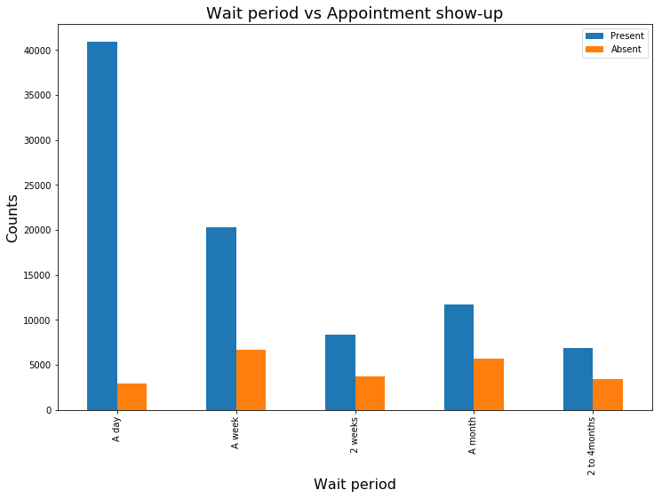

```python
df_wait_period = df.groupby('wait_period')['no_show'].value_counts().unstack()
df_wait_period.plot(kind = 'bar',figsize= (12,8))
plt.ylabel('Counts', fontsize=16)
plt.xlabel('Wait period', fontsize=16)
plt.title('Wait period vs Appointment show-up', fontsize=18)
plt.legend(['Present','Absent']);
df.groupby('wait_period')['no_show'].value_counts()
```

> Most patients that showed up for their appointment made the schedule within a short wait period of a day to 2 weeks.

### What is the relationship between Neighbourhood and their showing up for appointments?

> First, let us plot a bar chart to create a visual of counts per neighbourhood

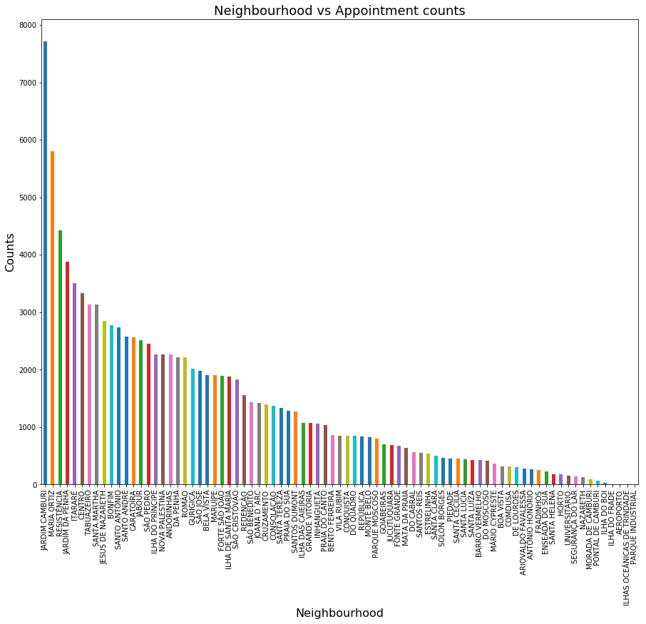

```python
df['neighbourhood'].value_counts().plot(kind='bar', figsize = (15,12));
plt.ylabel('Counts', fontsize=16)
plt.xlabel('Neighbourhood', fontsize=16)
plt.title('Neighbourhood vs Appointment counts', fontsize=18);
```

> Plot another bar chart showing distribution of neighbourhood against appointment show-up

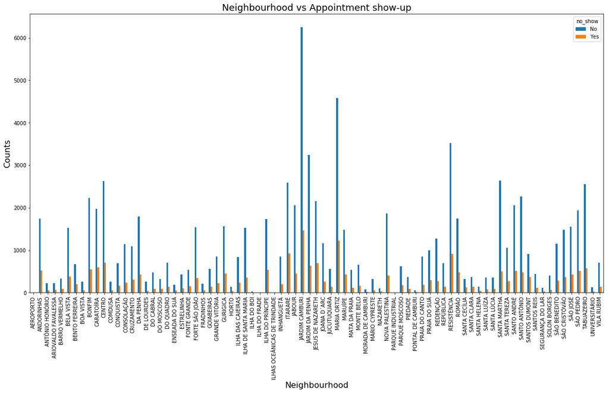

```python
df_hood = df.groupby('neighbourhood')['no_show'].value_counts().unstack()
df_hood.plot(kind = 'bar',figsize= (20,10))
plt.ylabel('Counts', fontsize=16)
plt.xlabel('Neighbourhood', fontsize=16)
plt.title('Neighbourhood vs Appointment show-up', fontsize=18);
```

> Jardim Camburi is the neighbourhood with the highest number of patients who scheduled appointments and showed up.

### Does receiving SMS reminder affect patients attendance to appointments?

> Some patients received SMS notification for their appointments. Let us plot a bar chart to analyze how it affected appointment show up

```
sms_received  no_show
0             No         62509
              Yes        12530
1             No         25698
              Yes         9784
Name: no_show, dtype: int64
```

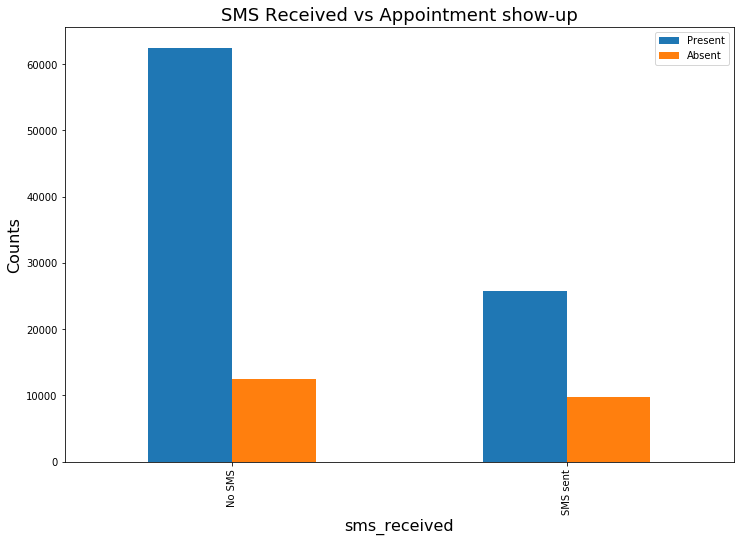

```python
df_sms = df.groupby('sms_received')['no_show'].value_counts().unstack()
df_sms.plot(kind = 'bar',figsize= (12,8))
plt.ylabel('Counts', fontsize=16)
plt.xlabel('sms_received', fontsize=16)
plt.xticks([0,1], ['No SMS', 'SMS sent'])
plt.title('SMS Received vs Appointment show-up', fontsize=18)
plt.legend(['Present','Absent'])
df.groupby('sms_received')['no_show'].value_counts()
```

> Most patients who did not receive SMS notification showed up for their appointments as against those that received.

## Conclusions

> From the analysis above:

> Approximately 20% of the total patients do not show up for appointments.

> More females than males schedule appointments.

> The bulk of appointments are from the age group 18 year olds to 60 year olds while infants and seniors tend to show up for their appointments more than other age categories.

> Patient with shorter waiting time tend to show-up more than those with longer waiting time. This implies that as the wait time increases probability of show up reduces.

### Limitations

> Data collection time is a bit too small to make predictions as regards patients no-show up factor (data is only for about 3 months).

> Information on proximity of each neighbourhood medical center and patients homes would be very useful in determining how patients show up for their appointments.

> More informations needs to be provided on major sickness/diseases types, in other words, the severity of the medical condition that prompt patients to book appointments

### References

- [Medical Appointments No Shows From Kaggle](https://www.kaggle.com/datasets/joniarroba/noshowappointments)
- [Pandas DataFrame Documentation](https://pandas.pydata.org/pandas-docs/stable/reference/frame.html)
- [Seaborn CountPlot Documentation](https://seaborn.pydata.org/generated/seaborn.countplot.html)
- [Creating Multiple Subplots - Google Search](https://matplotlib.org/stable/gallery/subplots_axes_and_figures/subplots_demo.html)

## Submitting your Project

```python
from subprocess import call
call(['python', '-m', 'nbconvert', 'Investigate_a_Dataset.ipynb'])
```

```
0
```